```python
import plotly.io as pio
pio.renderers.default = "png"
try:
    pio.kaleido.scope.default_format = "png"
except Exception:
    pass
```

# Quant Risk Core: Comprehensive Analysis Suite

This notebook provides a deep-dive into every module of the `quant_risk_core` repository, covering derivatives pricing, volatility modeling, portfolio risk, and credit risk.

### Environment Setup

This cell ensures all required libraries are installed in the current environment. It is designed for portability across local machines and cloud platforms like Google Colab.

```python
# Install dependencies silently if not present
import sys
!{sys.executable} -m pip install -q numpy scipy pandas arch statsmodels numba plotly yfinance
```

```python
import numpy as np
import pandas as pd
import plotly.graph_objects as go
import plotly.express as px
from plotly.subplots import make_subplots
import scipy.stats as stats
```

## 1. Derivatives Pricing: Black-Scholes & Greeks

The Black-Scholes model calculates the theoretical price of European options by modeling the underlying asset as a geometric Brownian motion. It is used to derive Greeks, which measure how sensitive an option's price is to changes in spot price, time, and volatility.

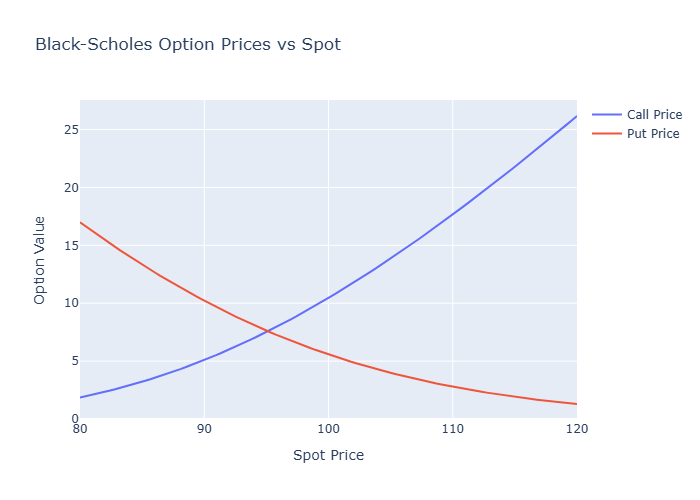

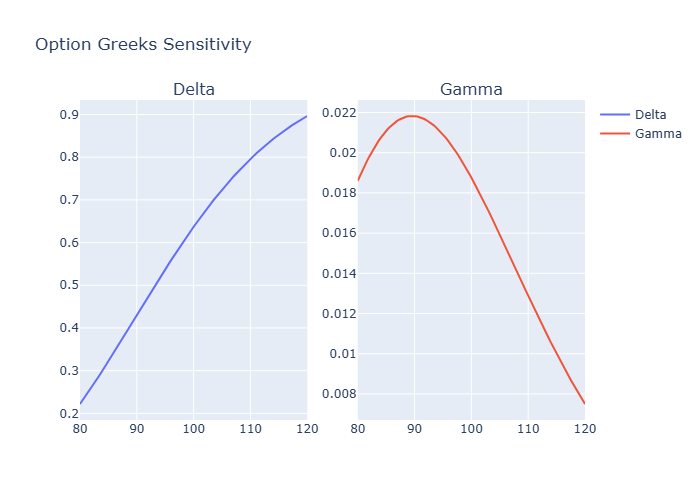

```python
from market_risk.pricing import BlackScholesEngine

S = np.linspace(80, 120, 100)
K, T, r, sigma = 100, 1.0, 0.05, 0.2

calls = BlackScholesEngine.calculate_prices(S, K, T, r, sigma, 'call')
puts = BlackScholesEngine.calculate_prices(S, K, T, r, sigma, 'put')

fig_bs = go.Figure()
fig_bs.add_trace(go.Scatter(x=S, y=calls, name='Call Price'))
fig_bs.add_trace(go.Scatter(x=S, y=puts, name='Put Price'))
fig_bs.update_layout(title='Black-Scholes Option Prices vs Spot', xaxis_title='Spot Price', yaxis_title='Option Value')
fig_bs.show()

# Sensitivity Analysis: Greeks
greeks = [BlackScholesEngine.calculate_greeks(s, K, T, r, sigma) for s in S]
deltas = [g['Delta'] for g in greeks]
gammas = [g['Gamma'] for g in greeks]

fig_greeks = make_subplots(rows=1, cols=2, subplot_titles=('Delta', 'Gamma'))
fig_greeks.add_trace(go.Scatter(x=S, y=deltas, name='Delta'), row=1, col=1)
fig_greeks.add_trace(go.Scatter(x=S, y=gammas, name='Gamma'), row=1, col=2)
fig_greeks.update_layout(title='Option Greeks Sensitivity')
fig_greeks.show()
```

## 2. Advanced Volatility: EGARCH & Regime Switching

EGARCH models capture asymmetric volatility, where market drops increase volatility more than gains, while Markov Regime Switching identifies shifts between distinct market states like bull and bear markets. These combined tools allow for a sophisticated understanding of how volatility clusters and evolves during different market phases.

```
EGARCH Gamma (Leverage Effect): 0.0000
```

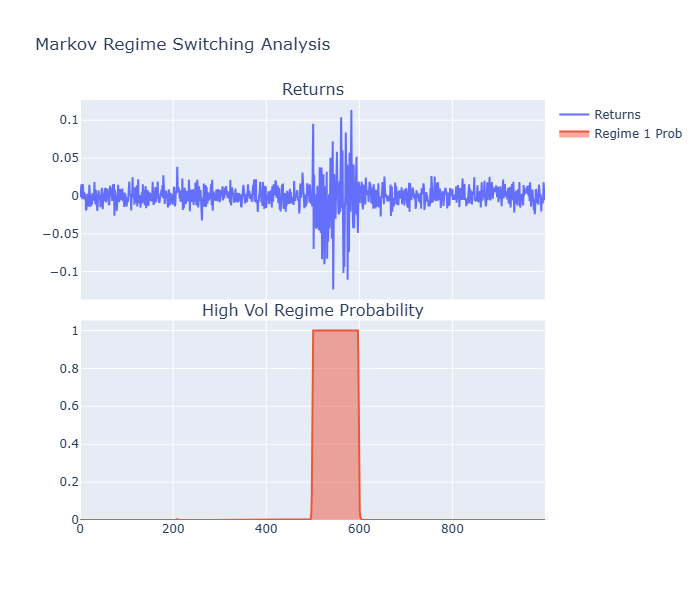

```python
from market_risk.volatility import GARCHEngine, RegimeSwitchingEngine

np.random.seed(42)
returns = np.random.normal(0, 0.01, 1000)
returns[500:600] *= 5 # High vol regime
returns_series = pd.Series(returns)

# EGARCH analysis
egarch = GARCHEngine()
egarch.fit(returns_series, model_type='EGARCH')
print(f'EGARCH Gamma (Leverage Effect): {egarch.gamma:.4f}')

# Regime Switching analysis
regime_eng = RegimeSwitchingEngine(k_regimes=2)
regime_eng.fit(returns_series)
probs = regime_eng.get_regime_probabilities()

fig_regime = make_subplots(rows=2, cols=1, shared_xaxes=True, vertical_spacing=0.05, subplot_titles=('Returns', 'High Vol Regime Probability'))
fig_regime.add_trace(go.Scatter(y=returns, name='Returns'), row=1, col=1)
fig_regime.add_trace(go.Scatter(y=probs.iloc[:, 1], name='Regime 1 Prob', fill='tozeroy'), row=2, col=1)
fig_regime.update_layout(height=600, title='Markov Regime Switching Analysis')
fig_regime.show()
```

## 3. Portfolio Risk: Copulas & Decomposition

Gaussian Copulas model the dependency between multiple assets, capturing how they move together regardless of their individual distributions. Risk Decomposition then breaks down total portfolio Value at Risk into individual asset contributions, allowing managers to identify and mitigate specific sources of risk.

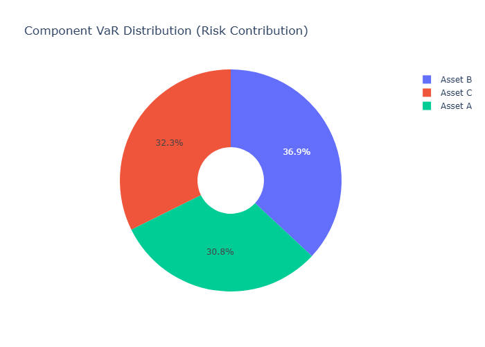

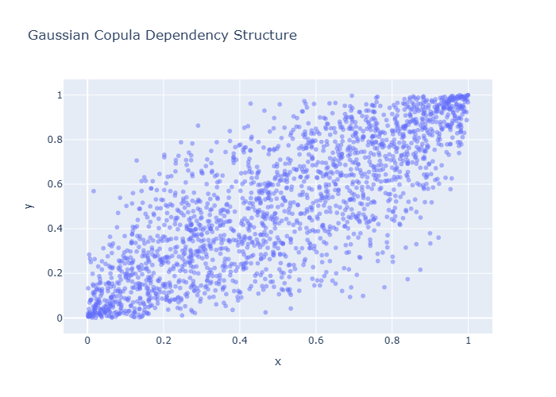

```python
from portfolio_risk.decomposition import RiskDecomposer, CopulaEngine

weights = np.array([0.4, 0.3, 0.3])
cov = np.array([
    [0.0004, 0.0001, 0.0002],
    [0.0001, 0.0009, 0.0003],
    [0.0002, 0.0003, 0.0006]
])

decomposer = RiskDecomposer(weights, cov)
mvar = decomposer.calculate_marginal_var(0.99)
cvar = decomposer.calculate_component_var(0.99)

fig_risk = go.Figure(data=[go.Pie(labels=['Asset A', 'Asset B', 'Asset C'], values=cvar, hole=.3)])
fig_risk.update_layout(title='Component VaR Distribution (Risk Contribution)')
fig_risk.show()

# Copula dependency visualization
corr = np.array([[1.0, 0.8], [0.8, 1.0]])
copula = CopulaEngine(corr)
samples = copula.generate_gaussian_copula_samples(2000)
fig_copula = px.scatter(x=samples[:, 0], y=samples[:, 1], opacity=0.5, title='Gaussian Copula Dependency Structure')
fig_copula.show()
```

## 4. Liquidity-Adjusted Risk & Stress Testing

Liquidity-Adjusted VaR (L-VaR) accounts for market friction by incorporating bid-ask spreads and price impact into risk estimates. Stress testing and correlation tilting simulate extreme market crashes and the breakdown of diversification to evaluate a portfolio's resilience under fire.

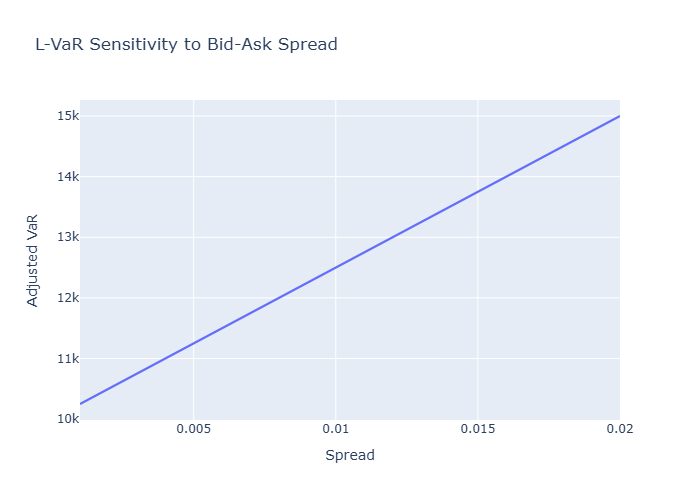

```
Original Correlation:
 [[1.  0.3]
 [0.3 1. ]]
Stressed Correlation (2.5x tilt):
 [[1.   0.75]
 [0.75 1.  ]]
```

```python
from market_risk.liquidity import LiquidityRiskEngine
from market_risk.stress_testing import FactorStresser

liquidity = LiquidityRiskEngine(position_size=5000, mid_price=100)
spreads = np.linspace(0.001, 0.02, 20)
l_vars = [liquidity.calculate_l_var(10000, s) for s in spreads]

fig_liq = go.Figure()
fig_liq.add_trace(go.Scatter(x=spreads, y=l_vars, name='L-VaR'))
fig_liq.update_layout(title='L-VaR Sensitivity to Bid-Ask Spread', xaxis_title='Spread', yaxis_title='Adjusted VaR')
fig_liq.show()

# Correlation stress
corr_orig = np.array([[1.0, 0.3], [0.3, 1.0]])
stressed_corr = FactorStresser.tilt_correlation(corr_orig, 2.5)
print('Original Correlation:\n', corr_orig)
print('Stressed Correlation (2.5x tilt):\n', stressed_corr)
```

## 5. Credit Risk: WWR, CVA & Migration

Credit Value Adjustment (CVA) prices the risk of counterparty default, with Wrong-Way Risk (WWR) specifically modeling the dangerous correlation between exposure and credit quality. Rating Migration simulations then track the stochastic evolution of credit ratings to estimate potential losses from credit downgrades over time.

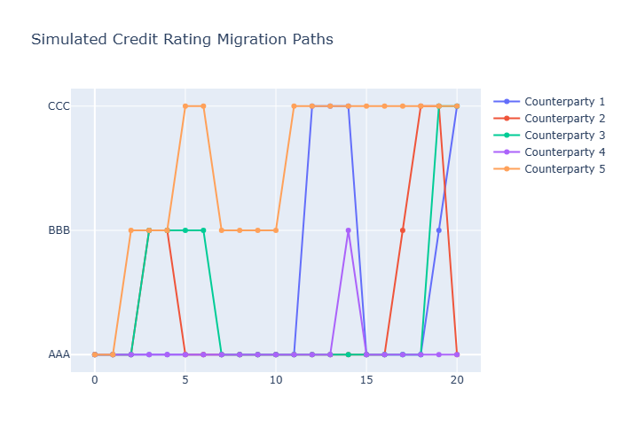

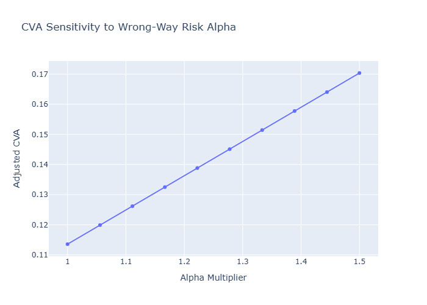

```python
from credit_risk.counterparty import RatingMigrationEngine, CounterpartyRiskEngine

# Rating Migration paths
tm = np.array([[0.9, 0.08, 0.02], [0.1, 0.8, 0.1], [0.05, 0.15, 0.8]])
mig_eng = RatingMigrationEngine(tm)
n_paths = 5
fig_mig = go.Figure()
for i in range(n_paths):
    path = mig_eng.simulate_migration(0, 20)
    fig_mig.add_trace(go.Scatter(y=path, mode='lines+markers', name=f'Counterparty {i+1}'))
fig_mig.update_layout(title='Simulated Credit Rating Migration Paths', yaxis=dict(tickvals=[0, 1, 2], ticktext=['AAA', 'BBB', 'CCC']))
fig_mig.show()

# WWR Impact
t_grid = np.linspace(0, 1, 10)
cpty = CounterpartyRiskEngine(t_grid)
cpty.set_portfolio_paths(np.random.normal(0, 10, (100, 10)))
pd_curv = np.linspace(0, 0.05, 10)
alphas = np.linspace(1.0, 1.5, 10)
wwr_cvas = [cpty.calculate_cva_wwr(0.4, pd_curv, a) for a in alphas]

fig_wwr = go.Figure()
fig_wwr.add_trace(go.Scatter(x=alphas, y=wwr_cvas))
fig_wwr.update_layout(title='CVA Sensitivity to Wrong-Way Risk Alpha', xaxis_title='Alpha Multiplier', yaxis_title='Adjusted CVA')
fig_wwr.show()
```

## 6. Real-time Market Data Integration

This module automates the fetching of live financial data from APIs like Yahoo Finance to keep risk models updated with current market conditions. It provides a seamless data pipeline that powers the entire analytical suite with real-world price action.

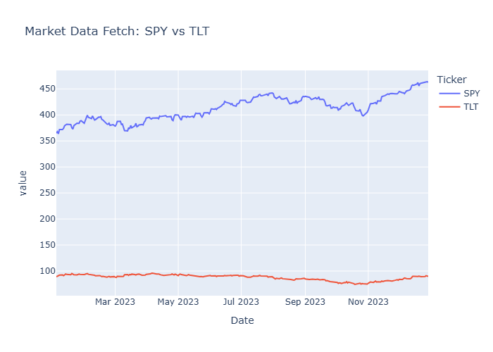

```python
from data.data_connectors import YahooFinanceConnector

try:
    prices = YahooFinanceConnector.fetch_historical_prices(['SPY', 'TLT'], '2023-01-01', '2024-01-01')
    fig_data = px.line(prices, title='Market Data Fetch: SPY vs TLT')
    fig_data.show()
except Exception as e:
    print(f'Data fetch skipped (possibly network/API limits): {e}')
```

# Part II: Real-World Portfolio Analytics Dashboard

In this section, we apply the `quant_risk_core` engine to a live, diversified portfolio of Equities, Crypto, and Commodities.

### 7. Multi-Asset Data Acquisition

We fetch the last 2 years of adjusted closing prices for a diversified basket: AAPL (Tech), MSFT (Tech), BTC-USD (Crypto), GLD (Gold), and SPY (Market). This provides a broad dataset to test our risk models across different asset classes and volatility profiles.

```python
from data.data_connectors import YahooFinanceConnector
tickers = ['AAPL', 'MSFT', 'BTC-USD', 'GLD', 'SPY']
raw_data = YahooFinanceConnector.fetch_historical_prices(tickers, '2022-01-01', '2024-05-20')
raw_data.tail()
```

| Ticker Date | AAPL | BTC-USD | GLD | MSFT | SPY |
| --- | --- | --- | --- | --- | --- |
| 2024-05-15 | 188.090652 | 66267.492188 | 220.889999 | 416.533783 | 517.192993 |
| 2024-05-16 | 188.209641 | 65231.582031 | 220.029999 | 414.476166 | 516.128967 |
| 2024-05-17 | 188.239365 | 67051.875000 | 223.660004 | 413.708282 | 516.870972 |
| 2024-05-18 | NaN | 66940.804688 | NaN | NaN | NaN |
| 2024-05-19 | NaN | 66278.367188 | NaN | NaN | NaN |

### 8. Returns Engineering & Sanitization

Using the `DataPreprocessor`, we convert raw prices into continuous log-returns while handling missing values and ensuring data stationarity. Log-returns are preferred in risk modeling because they are additive over time and more closely follow a normal distribution than simple returns.

```python
from market_risk.data_preprocessor import DataPreprocessor
preprocessor = DataPreprocessor()
returns_df = preprocessor.compute_log_returns(raw_data)
print(f'Returns shape: {returns_df.shape}')
returns_df.describe()
```

```
Returns shape: (867, 5)
```

| Ticker | AAPL | BTC-USD | GLD | MSFT | SPY |
| --- | --- | --- | --- | --- | --- |
| count | 867.000000 | 867.000000 | 867.000000 | 867.000000 | 867.000000 |
| mean | 0.000065 | 0.000410 | 0.000328 | 0.000287 | 0.000158 |
| std | 0.014697 | 0.029129 | 0.007401 | 0.015250 | 0.009651 |
| min | -0.060472 | -0.174053 | -0.030161 | -0.080295 | -0.044456 |
| 25% | -0.005014 | -0.011148 | -0.002396 | -0.004367 | -0.002658 |
| 50% | 0.000000 | -0.000258 | 0.000000 | 0.000000 | 0.000000 |
| 75% | 0.005116 | 0.013731 | 0.003075 | 0.005826 | 0.003455 |
| max | 0.085237 | 0.135764 | 0.031642 | 0.079059 | 0.053497 |

### 9. Comparative Performance Visualization

We visualize the cumulative growth of $1 invested in each asset to identify long-term trends and relative performance. This chart helps contextualize the risk metrics by showing the historical path and drawdown periods for each ticker.

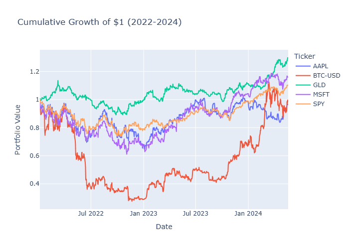

```python
cum_returns = (1 + returns_df).cumprod()
fig_cum = px.line(cum_returns, title='Cumulative Growth of $1 (2022-2024)', labels={'value': 'Portfolio Value', 'index': 'Date'})
fig_cum.show()
```

### 10. Multi-Asset Volatility Clustering

We fit GARCH(1,1) models to each asset to compare their conditional volatility over time. This highlights the 'Volatility Clustering' phenomenon where high-volatility periods are followed by high-volatility, particularly evident in the Crypto vs. Equity comparison.

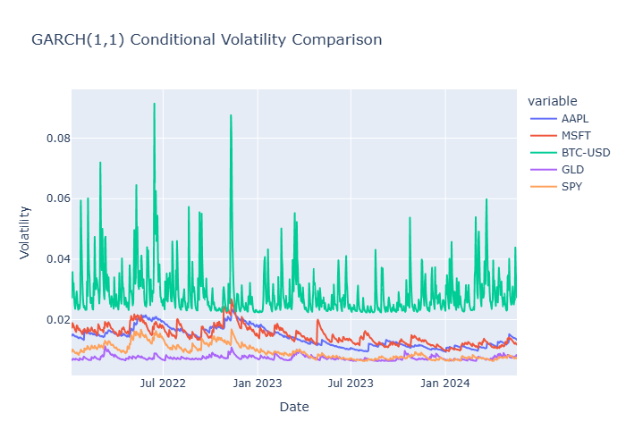

```python
from market_risk.volatility import GARCHEngine

vols_dict = {}
for ticker in tickers:
    g = GARCHEngine()
    g.fit(returns_df[ticker])
    vols_dict[ticker] = g.conditional_volatility()

vols_df = pd.DataFrame(vols_dict)
fig_vols = px.line(vols_df, title='GARCH(1,1) Conditional Volatility Comparison', labels={'value': 'Volatility', 'index': 'Date'})
fig_vols.show()
```

### 11. Market Risk Dashboard: Rolling 99% VaR

This dashboard maps the daily 99% Value at Risk for Bitcoin against its actual returns. It provides a visual validation of how well the GARCH-adjusted thresholds respond to rapid price movements and extreme market shocks.

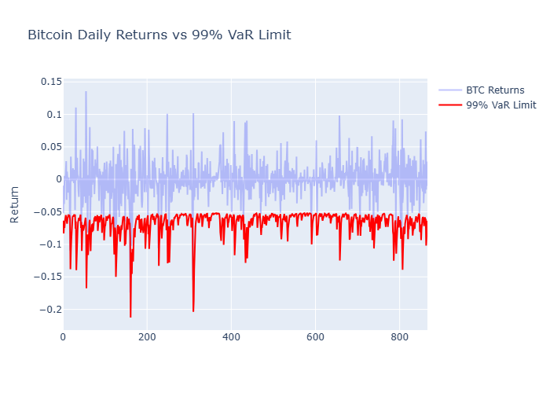

```python
from market_risk.estimators import RiskEngine
target_asset = 'BTC-USD'
risk_eng = RiskEngine(confidence_levels=[0.99])
btc_vars = [risk_eng.parametric_var_es(0, v, 'normal')['VaR_0.99'] for v in vols_df[target_asset]]

fig_btc_risk = go.Figure()
fig_btc_risk.add_trace(go.Scatter(y=returns_df[target_asset], name='BTC Returns', opacity=0.4))
fig_btc_risk.add_trace(go.Scatter(y=-np.array(btc_vars), name='99% VaR Limit', line=dict(color='red')))
fig_btc_risk.update_layout(title=f'Bitcoin Daily Returns vs 99% VaR Limit', yaxis_title='Return')
fig_btc_risk.show()
```

### 12. Cross-Asset Correlation Dynamics

We generate a correlation matrix to understand the diversification benefits of the portfolio. Low or negative correlations between assets like Gold (GLD) and Equities (SPY) are crucial for reducing total portfolio variance during market stress.

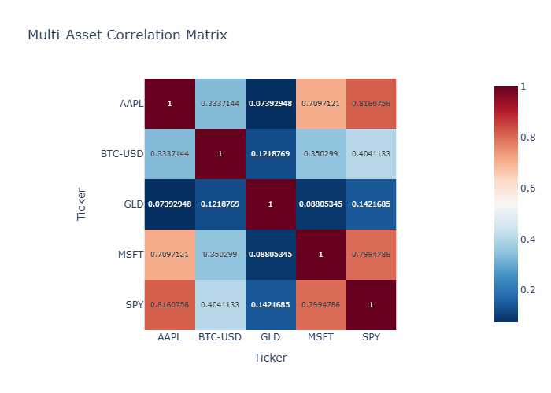

```python
corr_matrix = returns_df.corr()
fig_corr = px.imshow(corr_matrix, text_auto=True, color_continuous_scale='RdBu_r', title='Multi-Asset Correlation Matrix')
fig_corr.show()
```

### 13. Portfolio Risk Contribution (Component VaR)

Assuming an equal-weighted portfolio, we decompose the total risk into individual asset contributions. This identifies which assets are 'risk-drivers' and which are 'diversifiers' based on their stand-alone volatility and their correlation with the rest of the basket.

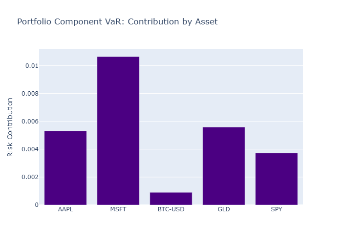

```python
from portfolio_risk.decomposition import RiskDecomposer
n_assets = len(tickers)
weights = np.array([1/n_assets] * n_assets)
cov_matrix = returns_df.cov()

decomposer = RiskDecomposer(weights, cov_matrix.values)
cvar_contributions = decomposer.calculate_component_var(0.99)

fig_port_risk = go.Figure(data=[go.Bar(x=tickers, y=cvar_contributions, marker_color='indigo')])
fig_port_risk.update_layout(title='Portfolio Component VaR: Contribution by Asset', yaxis_title='Risk Contribution')
fig_port_risk.show()
```

### 14. Scenario Analysis: Stressing the Portfolio

```python
from market_risk.stress_testing import ScenarioEngine
scenario_eng = ScenarioEngine(raw_data.tail(1))
shocks = {'BTC-USD': -0.20, 'GLD': 0.05}
stressed_prices = scenario_eng.apply_hypothetical_scenario(shocks)

print('Original Portfolio Prices (Recent):\n', raw_data.tail(1))
print('\nStressed Portfolio Prices (20% BTC Crash, 5% GLD Rally):\n', stressed_prices)
```

```
Original Portfolio Prices (Recent):
 Ticker      AAPL       BTC-USD  GLD  MSFT  SPY
Date
2024-05-19   NaN  66278.367188  NaN   NaN  NaN

Stressed Portfolio Prices (20% BTC Crash, 5% GLD Rally):
 Ticker      AAPL      BTC-USD  GLD  MSFT  SPY
Date
2024-05-19   NaN  53022.69375  NaN   NaN  NaN
```

### 15. Final Risk Summary Dashboard

We aggregate the key risk metrics-Annualized Volatility, 99% VaR, and Expected Shortfall-for all assets into a single dashboard. This provides a clear, actionable comparison of the risk-return profile across the entire investment universe.

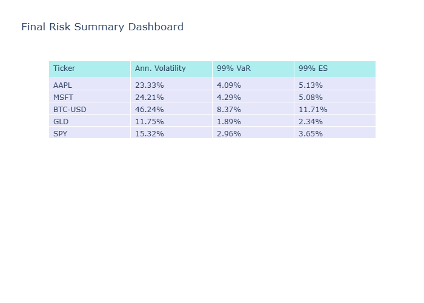

```python
summary_stats = []
for ticker in tickers:
    rets = returns_df[ticker]
    ann_vol = rets.std() * np.sqrt(252)
    risk = risk_eng.historical_var_es(rets)
    summary_stats.append({
        'Ticker': ticker,
        'Ann. Volatility': f'{ann_vol:.2%}',
        '99% VaR': f'{risk["VaR_0.99"]:.2%}',
        '99% ES': f'{risk["ES_0.99"]:.2%}'
    })

summary_df = pd.DataFrame(summary_stats)
fig_table = go.Figure(data=[go.Table(
    header=dict(values=list(summary_df.columns), fill_color='paleturquoise', align='left'),
    cells=dict(values=[summary_df[c] for c in summary_df.columns], fill_color='lavender', align='left'))
])
fig_table.update_layout(title='Final Risk Summary Dashboard')
fig_table.show()
```